# Publication figure report

none

manual

**Important**

A manual command generated this report without an LLM model. No separate human scientific review is part of this fixed recipe. The report records the selected recipe and does not claim a new method.

## Figure

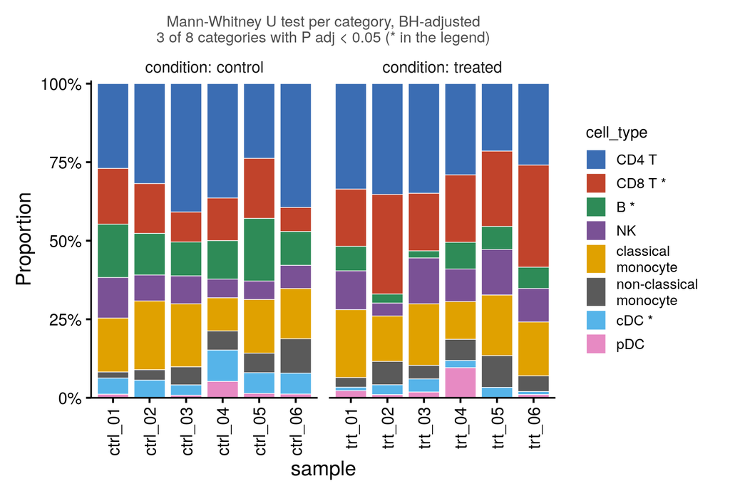

Publication figure

## Statistical results

| category | group | n_samples | mean_proportion | sd_proportion | median_proportion | test | statistic | p_value | p_adj | significant |
| --- | --- | --- | --- | --- | --- | --- | --- | --- | --- | --- |
| CD4 T | control | 6 | 0.332208168870303 | 0.0687940101359802 | 0.341089013545484 | Mann-Whitney U test | 24 | 0.393939393939394 | 0.63030303030303 | FALSE |
| CD4 T | treated | 6 | 0.300447548432715 | 0.0556748816296733 | 0.313276380663764 | Mann-Whitney U test | 24 | 0.393939393939394 | 0.63030303030303 | FALSE |
| CD8 T | control | 6 | 0.139127983068533 | 0.0455585988427352 | 0.147153051311903 | Mann-Whitney U test | 2 | 0.00865800865800866 | 0.0230880230880231 | TRUE |
| CD8 T | treated | 6 | 0.243526011844113 | 0.0636964042404072 | 0.227077856797111 | Mann-Whitney U test | 2 | 0.00865800865800866 | 0.0230880230880231 | TRUE |
| B | control | 6 | 0.1398820880054 | 0.0369963978193718 | 0.127395717579274 | Mann-Whitney U test | 36 | 0.00216450216450216 | 0.0173160173160173 | TRUE |
| B | treated | 6 | 0.0592479409606045 | 0.0266483008769235 | 0.0704854324526231 | Mann-Whitney U test | 36 | 0.00216450216450216 | 0.0173160173160173 | TRUE |
| NK | control | 6 | 0.0821522581508937 | 0.0259976143106316 | 0.0782394990992455 | Mann-Whitney U test | 9 | 0.17965367965368 | 0.359307359307359 | FALSE |
| NK | treated | 6 | 0.111022856460154 | 0.0387729376159205 | 0.115128199620159 | Mann-Whitney U test | 9 | 0.17965367965368 | 0.359307359307359 | FALSE |
| classical monocyte | control | 6 | 0.171142527003473 | 0.0389682974426325 | 0.170985869528363 | Mann-Whitney U test | 17 | 0.937229437229437 | 0.937229437229437 | FALSE |
| classical monocyte | treated | 6 | 0.173468487560949 | 0.0356617092340613 | 0.182228913519639 | Mann-Whitney U test | 17 | 0.937229437229437 | 0.937229437229437 | FALSE |
| non-classical monocyte | control | 6 | 0.0571348072611744 | 0.0309430603650714 | 0.0592254049812366 | Mann-Whitney U test | 16 | 0.818181818181818 | 0.935064935064935 | FALSE |
| non-classical monocyte | treated | 6 | 0.0611512769956904 | 0.0251660398553922 | 0.0586789329901709 | Mann-Whitney U test | 16 | 0.818181818181818 | 0.935064935064935 | FALSE |
| cDC | control | 6 | 0.0618814987699672 | 0.0222403686311554 | 0.0605146414446405 | Mann-Whitney U test | 35 | 0.00432900432900433 | 0.0173160173160173 | TRUE |
| cDC | treated | 6 | 0.0247473285192062 | 0.012781803900643 | 0.0271711104815902 | Mann-Whitney U test | 35 | 0.00432900432900433 | 0.0173160173160173 | TRUE |
| pDC | control | 6 | 0.0164706688702549 | 0.0180612269185234 | 0.0116676379176379 | Mann-Whitney U test | 15 | 0.699134199134199 | 0.932178932178932 | FALSE |
| pDC | treated | 6 | 0.026388549226568 | 0.0348192937780322 | 0.0142929668373788 | Mann-Whitney U test | 15 | 0.699134199134199 | 0.932178932178932 | FALSE |

## Methods

The counts of 8 categories of cell_type were summed within each of 12 samples (sample) and converted to proportions of the sample total. The samples fall into 2 groups (control: n = 6, treated: n = 6). For each category, the per-sample proportions were compared between the groups with the Mann-Whitney U test (two-sided, with the exact null distribution when there are fewer than 50 samples per group and no ties), and the P values were adjusted across the 8 categories with the Benjamini-Hochberg method; 3 categories had an adjusted P below 0.05. Proportions are compositional: they sum to one within each sample, so a rise in one category forces the others down and the per-category tests are not independent. The tests are therefore exploratory; a compositional method, for example a log-ratio transform, is needed for a confirmatory claim. Computed in R 4.4.1 and drawn with ggplot2 3.5.1.

## Plot configuration

The complete plot configuration is in `plot_config.yaml`.

## Provenance

| field | value |
| --- | --- |
| repository | pubready |
| repository_version | 4.0.0 |
| git_commit | 567ce8900bdb5db88369d131c8d787b042b3af57 |
| git_dirty | FALSE |
| llm_provider | none |
| llm_model | none |
| agent_harness | manual |
| agent_harness_version | not_recorded |
| container_image | localhost/pubready:4.0.0 |
| container_digest | sha256:0f57027a3fbca5ec9d41d74ca91226fbdf45d94b1a85f271637d12733db5d483 |
| input | {“file”:“input_cell_type.csv”,“md5”:“4a74ef936bfc21d4bf2ccebb6e699014”,“sha256”:“329d74c430d92f2d03a0ec9b91979eaa4ead49770e328224a89d2665269c7910”} |
| command | figkit plot –recipe composition |
| analysis_options | {“engine”:“r”,“recipe”:“composition”,“data”:{“file”:“composition.csv”,“x”:“cell_type”,“y”:“n_cells”,“fill”:null,“facet”:null,“time”:null,“event”:null,“annotation”:null,“id”:“sample”,“group”:“condition… |
| random_seeds | not_applicable |
| session_record | session_info.txt |
| created_utc | 2026-07-18T00:00:00Z |
| review_state | not_applicable |
| reviewer | none |
| quarto_version | 1.11.4 |

The report source reads only files in this bundle.